# Analysis of Red Wine Chemical Attributes by Javier Ortiz

```
##   X fixed.acidity volatile.acidity citric.acid residual.sugar chlorides
## 1 1           7.4             0.70        0.00            1.9     0.076
## 2 2           7.8             0.88        0.00            2.6     0.098
## 3 3           7.8             0.76        0.04            2.3     0.092
## 4 4          11.2             0.28        0.56            1.9     0.075
## 5 5           7.4             0.70        0.00            1.9     0.076
## 6 6           7.4             0.66        0.00            1.8     0.075
##   free.sulfur.dioxide total.sulfur.dioxide density   pH sulphates alcohol
## 1                  11                   34  0.9978 3.51      0.56     9.4
## 2                  25                   67  0.9968 3.20      0.68     9.8
## 3                  15                   54  0.9970 3.26      0.65     9.8
## 4                  17                   60  0.9980 3.16      0.58     9.8
## 5                  11                   34  0.9978 3.51      0.56     9.4
## 6                  13                   40  0.9978 3.51      0.56     9.4
##   quality
## 1       5
## 2       5
## 3       5
## 4       6
## 5       5
## 6       5
```

```
## [1] 1599
```

The Red Wine Quality data set contains information about over 1,500 red wines with 11 variables that describe the chemical characteristics of wine. The data set provides a rating of the quality of each wine, with 0 being the lowest quality and 10 being the greatest quality.

Some questions that would be relevant to this dataset are what chemical characteristics do quality wines share, do wines with higher alcohol content receive better ratings, do sweeter wines receive better ratings, what level of acidity is associated with higher quality wines.

# Univariate Plots Section

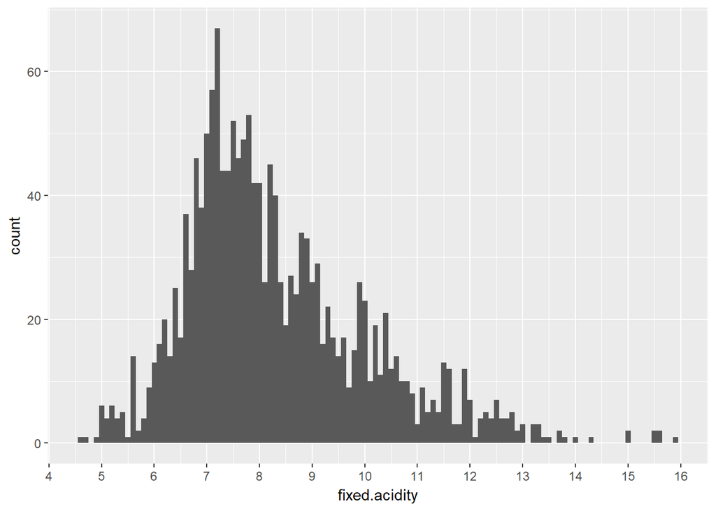

The histogram for fixed acidity is right skewed. Most of the observations fall in the 7-8 range.

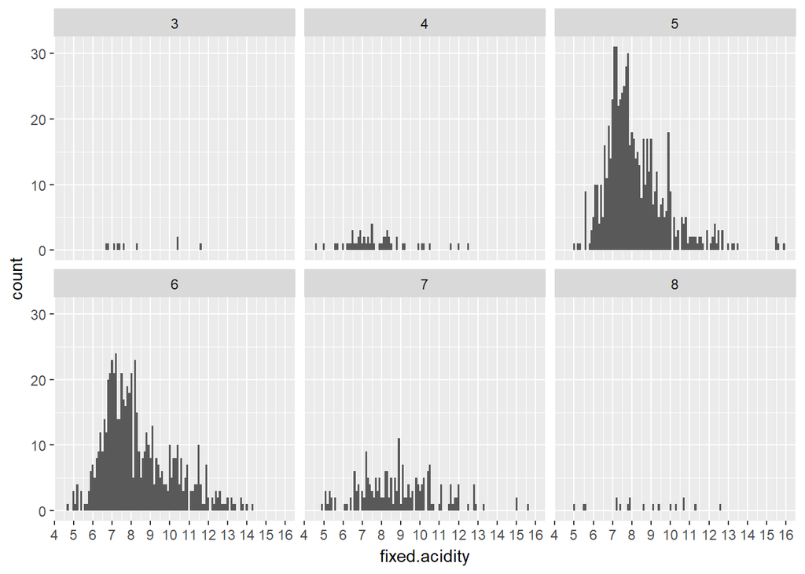

I was hoping to find a different distribution of fixed acidity for higher quality wines, but the distributions for all the wine qualities seem similar with most observations falling in the 6 to 11 range.

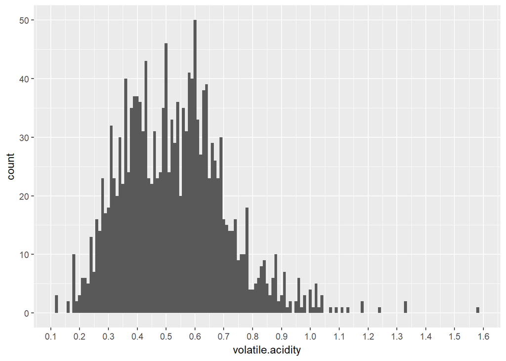

The distribution for volatile.acidity is more disperse, but still, most of the observations fall in the lower half of the values, between .3 and .7 with some outliers having values around 1.6.

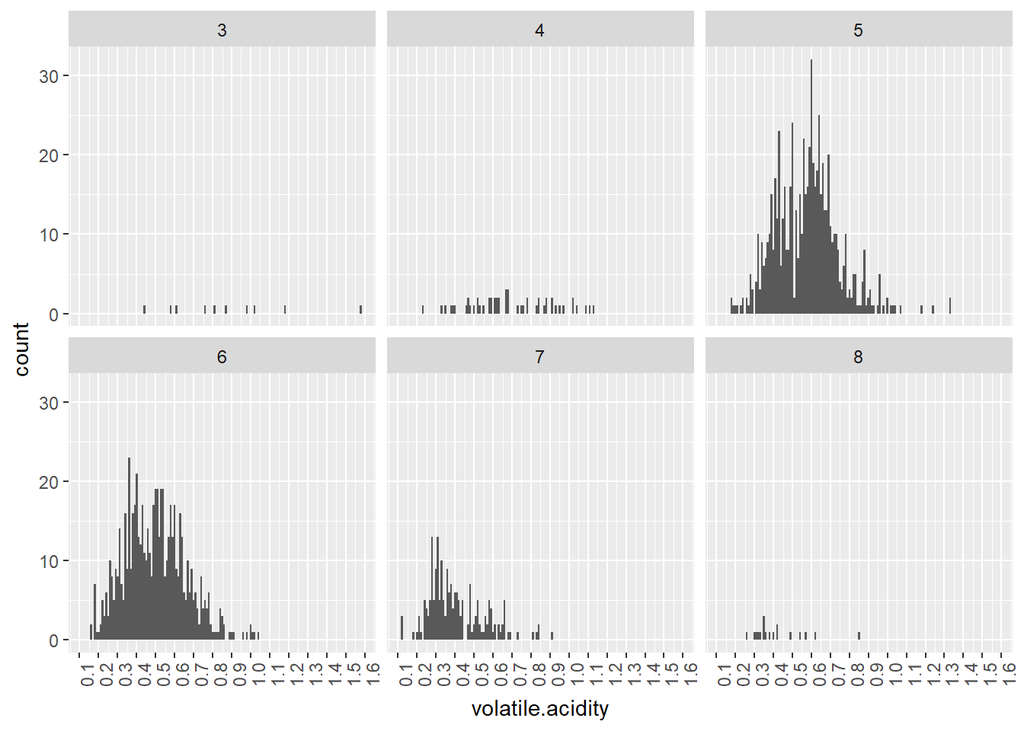

Volatile acidity is the amount of acetic acid in wine which according to the text file that comes with the data set, at too high levels might give an unpleasant taste to the wine. We can notice that higher quality wines do have a slighltly smaller value for volatile acidity in comparison to the lesser quality wines.

```
## reds$quality: 3
##    Min. 1st Qu.  Median    Mean 3rd Qu.    Max.
##  0.4400  0.6475  0.8450  0.8845  1.0100  1.5800
## --------------------------------------------------------
## reds$quality: 4
##    Min. 1st Qu.  Median    Mean 3rd Qu.    Max.
##   0.230   0.530   0.670   0.694   0.870   1.130
## --------------------------------------------------------
## reds$quality: 5
##    Min. 1st Qu.  Median    Mean 3rd Qu.    Max.
##   0.180   0.460   0.580   0.577   0.670   1.330
## --------------------------------------------------------
## reds$quality: 6
##    Min. 1st Qu.  Median    Mean 3rd Qu.    Max.
##  0.1600  0.3800  0.4900  0.4975  0.6000  1.0400
## --------------------------------------------------------
## reds$quality: 7
##    Min. 1st Qu.  Median    Mean 3rd Qu.    Max.
##  0.1200  0.3000  0.3700  0.4039  0.4850  0.9150
## --------------------------------------------------------
## reds$quality: 8
##    Min. 1st Qu.  Median    Mean 3rd Qu.    Max.
##  0.2600  0.3350  0.3700  0.4233  0.4725  0.8500
```

There seems to be a trend for volatile acidity, that decreases as the wine quality improves. Wine qualities of 7 and 8 have the lowest medians for this value with .3700, while lower quality wines have a median of .8450.

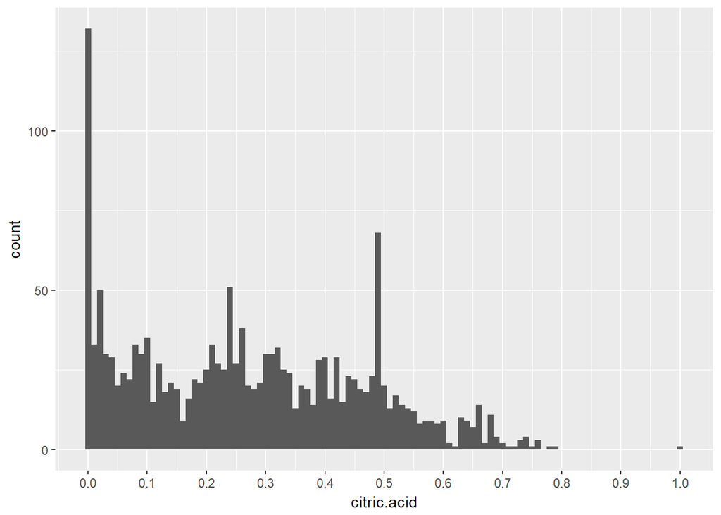

Even though most of the observations fall in the lower half of the distribution, there is one clear peak around the value of 0 and another less pronounced peak at around the value of 0.5.

```
## reds$quality: 3
##    Min. 1st Qu.  Median    Mean 3rd Qu.    Max.
##  0.0000  0.0050  0.0350  0.1710  0.3275  0.6600
## --------------------------------------------------------
## reds$quality: 4
##    Min. 1st Qu.  Median    Mean 3rd Qu.    Max.
##  0.0000  0.0300  0.0900  0.1742  0.2700  1.0000
## --------------------------------------------------------
## reds$quality: 5
##    Min. 1st Qu.  Median    Mean 3rd Qu.    Max.
##  0.0000  0.0900  0.2300  0.2437  0.3600  0.7900
## --------------------------------------------------------
## reds$quality: 6
##    Min. 1st Qu.  Median    Mean 3rd Qu.    Max.
##  0.0000  0.0900  0.2600  0.2738  0.4300  0.7800
## --------------------------------------------------------
## reds$quality: 7
##    Min. 1st Qu.  Median    Mean 3rd Qu.    Max.
##  0.0000  0.3050  0.4000  0.3752  0.4900  0.7600
## --------------------------------------------------------
## reds$quality: 8
##    Min. 1st Qu.  Median    Mean 3rd Qu.    Max.
##  0.0300  0.3025  0.4200  0.3911  0.5300  0.7200
```

There is a clear trend with the means and medians for citric acid, which increases as the wine quality increases. The lowest quality wines have a mean of .1710 and the highest quality wines a mean of .3911.

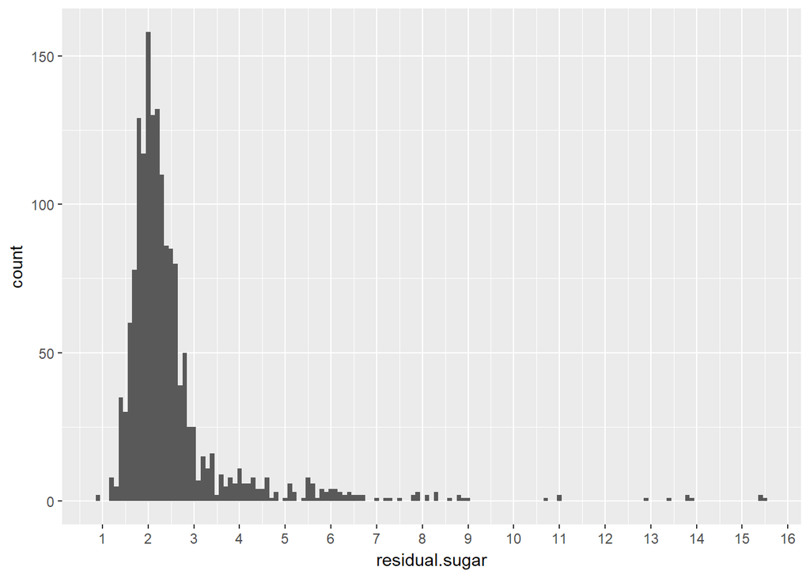

The histogram for residual sugar is right skewed. Most of the observations have a value of 2.

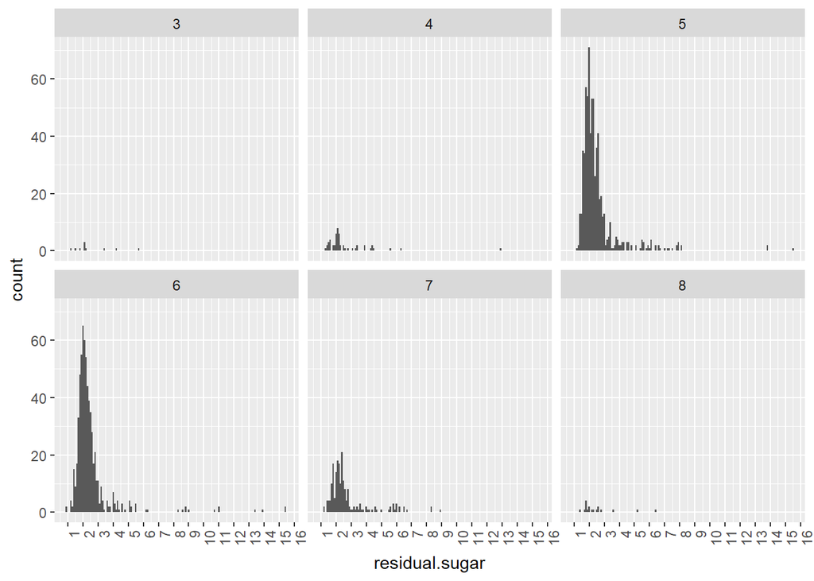

It doesn’t seem that residual sugar is a distinctive characteristic of higher quality wines.

```
## reds$quality: 3
##    Min. 1st Qu.  Median    Mean 3rd Qu.    Max.
##   1.200   1.875   2.100   2.635   3.100   5.700
## --------------------------------------------------------
## reds$quality: 4
##    Min. 1st Qu.  Median    Mean 3rd Qu.    Max.
##   1.300   1.900   2.100   2.694   2.800  12.900
## --------------------------------------------------------
## reds$quality: 5
##    Min. 1st Qu.  Median    Mean 3rd Qu.    Max.
##   1.200   1.900   2.200   2.529   2.600  15.500
## --------------------------------------------------------
## reds$quality: 6
##    Min. 1st Qu.  Median    Mean 3rd Qu.    Max.
##   0.900   1.900   2.200   2.477   2.500  15.400
## --------------------------------------------------------
## reds$quality: 7
##    Min. 1st Qu.  Median    Mean 3rd Qu.    Max.
##   1.200   2.000   2.300   2.721   2.750   8.900
## --------------------------------------------------------
## reds$quality: 8
##    Min. 1st Qu.  Median    Mean 3rd Qu.    Max.
##   1.400   1.800   2.100   2.578   2.600   6.400
```

All qualities of wine have a very close mean for residual sugar.

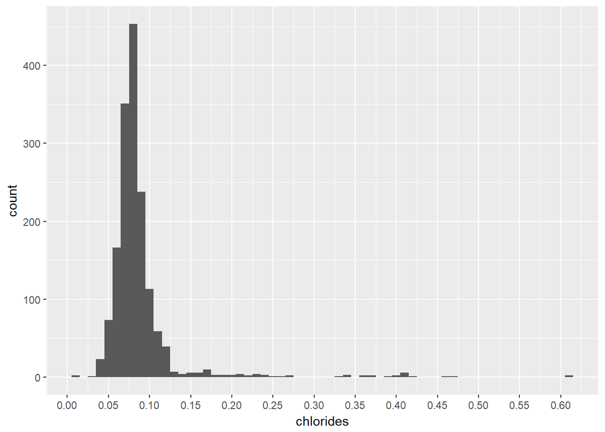

The distribution for chlorides is heavily skewed to the right, with the vast majority of observations falling in the .05 and .1 range.

```
## reds$quality: 3
##    Min. 1st Qu.  Median    Mean 3rd Qu.    Max.
##  0.0610  0.0790  0.0905  0.1225  0.1430  0.2670
## --------------------------------------------------------
## reds$quality: 4
##    Min. 1st Qu.  Median    Mean 3rd Qu.    Max.
## 0.04500 0.06700 0.08000 0.09068 0.08900 0.61000
## --------------------------------------------------------
## reds$quality: 5
##    Min. 1st Qu.  Median    Mean 3rd Qu.    Max.
## 0.03900 0.07400 0.08100 0.09274 0.09400 0.61100
## --------------------------------------------------------
## reds$quality: 6
##    Min. 1st Qu.  Median    Mean 3rd Qu.    Max.
## 0.03400 0.06825 0.07800 0.08496 0.08800 0.41500
## --------------------------------------------------------
## reds$quality: 7
##    Min. 1st Qu.  Median    Mean 3rd Qu.    Max.
## 0.01200 0.06200 0.07300 0.07659 0.08700 0.35800
## --------------------------------------------------------
## reds$quality: 8
##    Min. 1st Qu.  Median    Mean 3rd Qu.    Max.
## 0.04400 0.06200 0.07050 0.06844 0.07550 0.08600
```

It turns out that high quality wines have the lowest mean for the value of chlorides with .06844 while low quality wines have a mean of .1225.

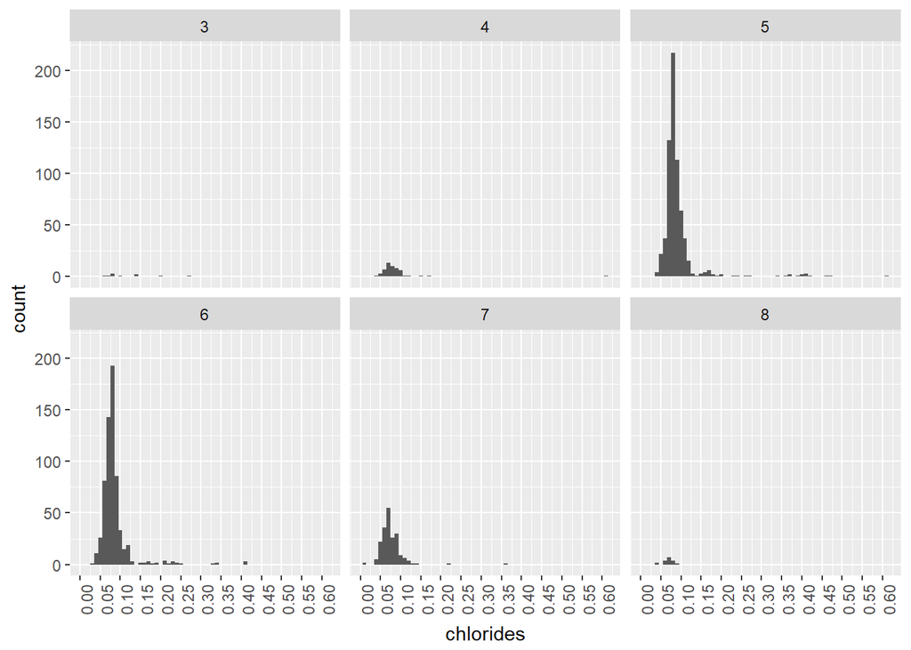

The distribution for chlorides is very similar for all the different wine qualities.

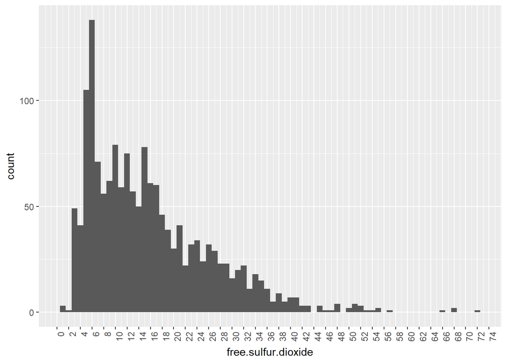

The distribution for free sulfur dioxide is right skewed, with most of the observations falling between the 4 and 18 range. There are some outliers far above the value of 58.

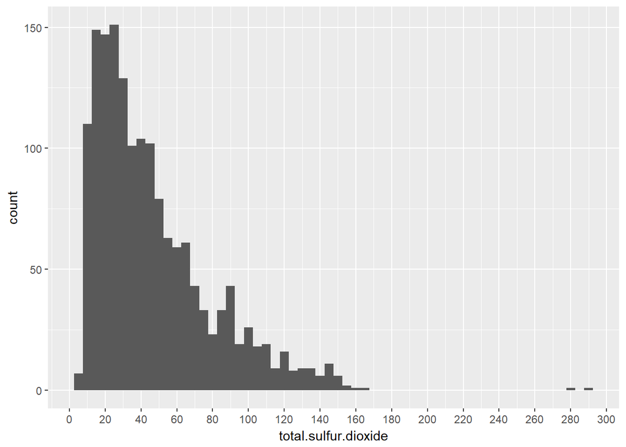

The distribution for total sulfur dioxide is right skewed with most of the observations falling in the 15 - 25 range. There are some outliers around the 280 value.

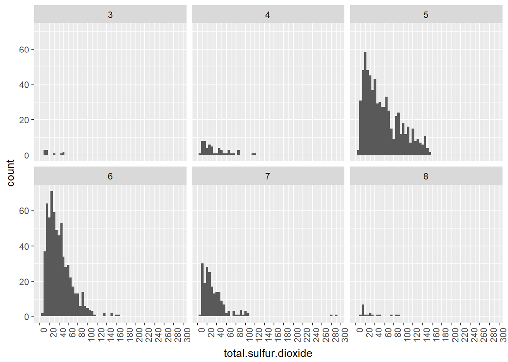

All the rankings for quality have a small number for total sulfur dioxide, however there are some outliers with high values for wine quality number 7.

```
## reds$quality: 3
##    Min. 1st Qu.  Median    Mean 3rd Qu.    Max.
##     9.0    12.5    15.0    24.9    42.5    49.0
## --------------------------------------------------------
## reds$quality: 4
##    Min. 1st Qu.  Median    Mean 3rd Qu.    Max.
##    7.00   14.00   26.00   36.25   49.00  119.00
## --------------------------------------------------------
## reds$quality: 5
##    Min. 1st Qu.  Median    Mean 3rd Qu.    Max.
##    6.00   26.00   47.00   56.51   84.00  155.00
## --------------------------------------------------------
## reds$quality: 6
##    Min. 1st Qu.  Median    Mean 3rd Qu.    Max.
##    6.00   23.00   35.00   40.87   54.00  165.00
## --------------------------------------------------------
## reds$quality: 7
##    Min. 1st Qu.  Median    Mean 3rd Qu.    Max.
##    7.00   17.50   27.00   35.02   43.00  289.00
## --------------------------------------------------------
## reds$quality: 8
##    Min. 1st Qu.  Median    Mean 3rd Qu.    Max.
##   12.00   16.00   21.50   33.44   43.00   88.00
```

I thought that a low level of total sulfur dioxide might be an attribute of high quality wines, but bad quality wines actually have a lower median and mean for this value.

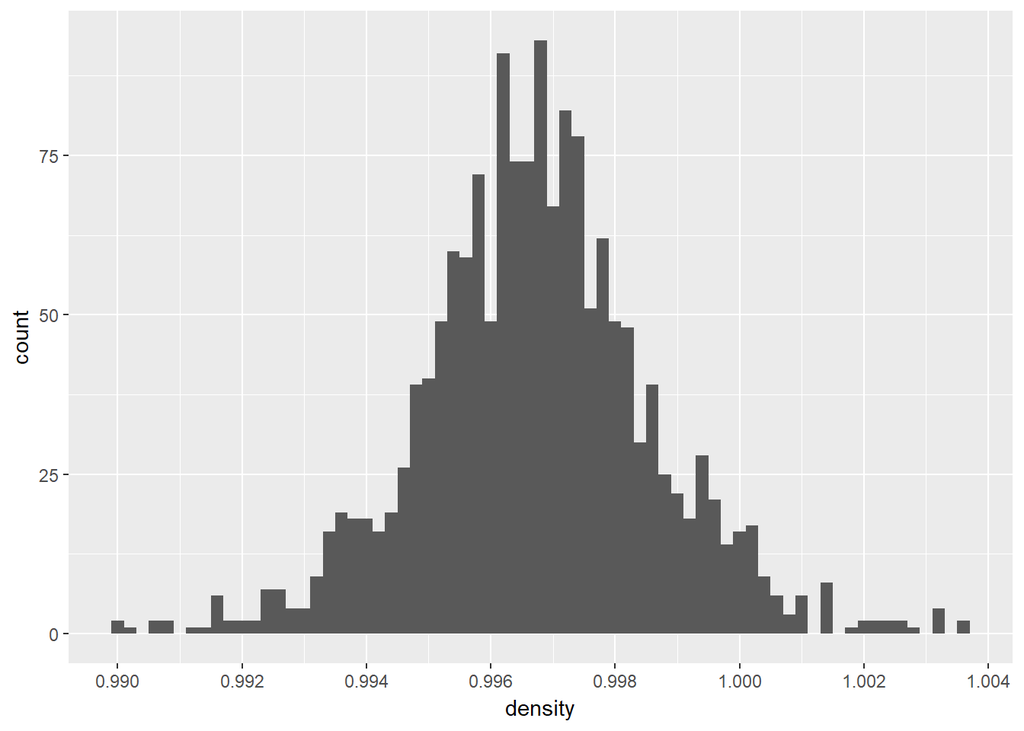

The observations for density are normally distributed with most values being between .996 and .998.

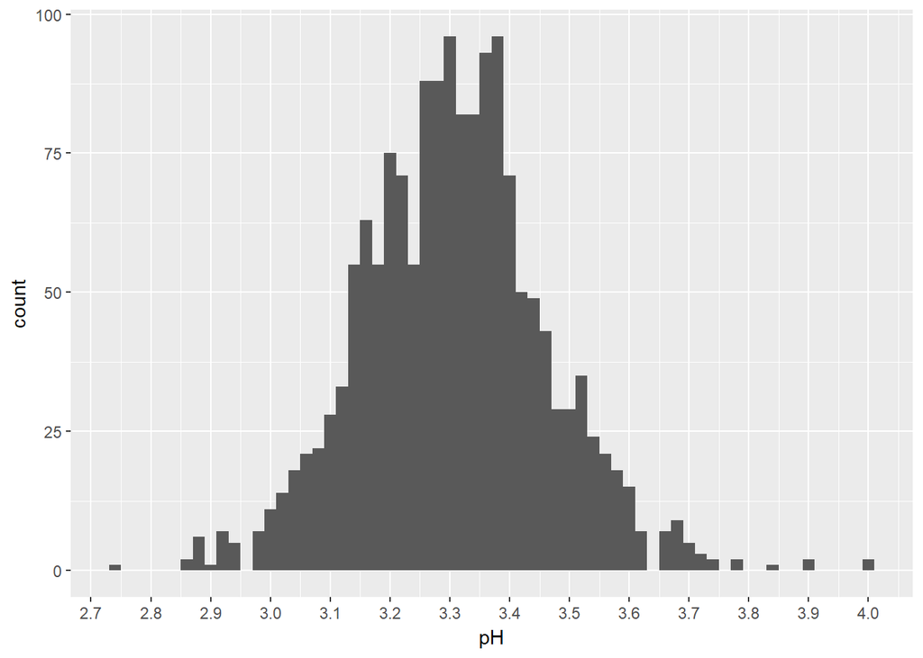

The pH variable follows a normal distribution with most of the observations falling between the 3.2 and 3.4 values.

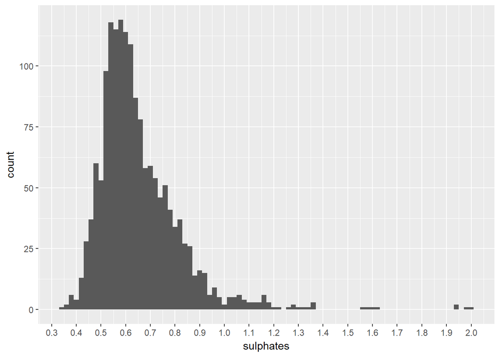

The distribution for sulphates is right skewed, with most of the observations falling in the .5 - .7 range, with some outliers near the value of 2.

```
## reds$quality: 3
##    Min. 1st Qu.  Median    Mean 3rd Qu.    Max.
##  0.4000  0.5125  0.5450  0.5700  0.6150  0.8600
## --------------------------------------------------------
## reds$quality: 4
##    Min. 1st Qu.  Median    Mean 3rd Qu.    Max.
##  0.3300  0.4900  0.5600  0.5964  0.6000  2.0000
## --------------------------------------------------------
## reds$quality: 5
##    Min. 1st Qu.  Median    Mean 3rd Qu.    Max.
##   0.370   0.530   0.580   0.621   0.660   1.980
## --------------------------------------------------------
## reds$quality: 6
##    Min. 1st Qu.  Median    Mean 3rd Qu.    Max.
##  0.4000  0.5800  0.6400  0.6753  0.7500  1.9500
## --------------------------------------------------------
## reds$quality: 7
##    Min. 1st Qu.  Median    Mean 3rd Qu.    Max.
##  0.3900  0.6500  0.7400  0.7413  0.8300  1.3600
## --------------------------------------------------------
## reds$quality: 8
##    Min. 1st Qu.  Median    Mean 3rd Qu.    Max.
##  0.6300  0.6900  0.7400  0.7678  0.8200  1.1000
```

When we calculate the mean sulphates for every quality ranking, we can notice that the mean sulphate level increases as the quality of wine improves. Low quality wines have a sulphates mean of .5700, while high quality wines have a mean of .7678.

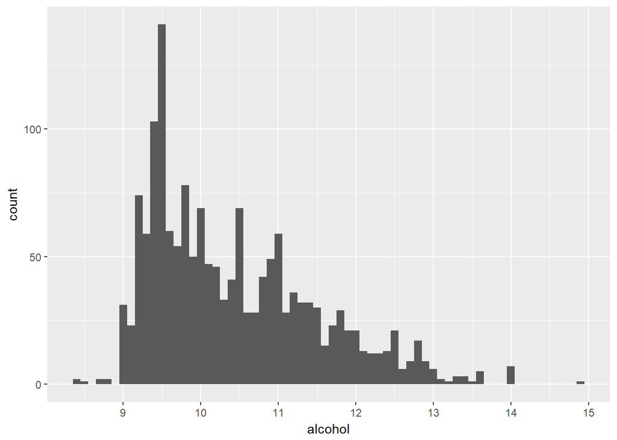

The alcohol content varies between 8 and 15, with most observations falling between 9.20 and 10.5.

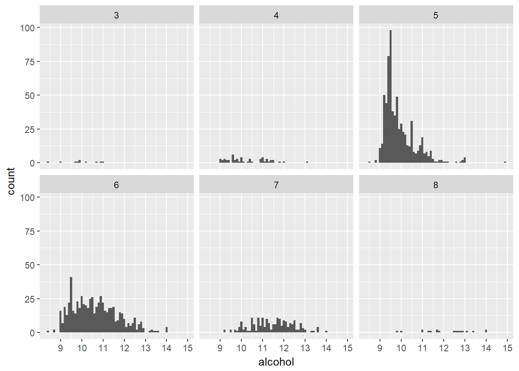

When we look at the alcohol levels by each quality ranking we can notice that most wines have a quality of 5. The lowest quality wines also have the lowest alcohol content, under 11, while the highest quality wines, have an alcohol content above 11. The middle quality wines have a more disperse alcohol content between 9 and 12.

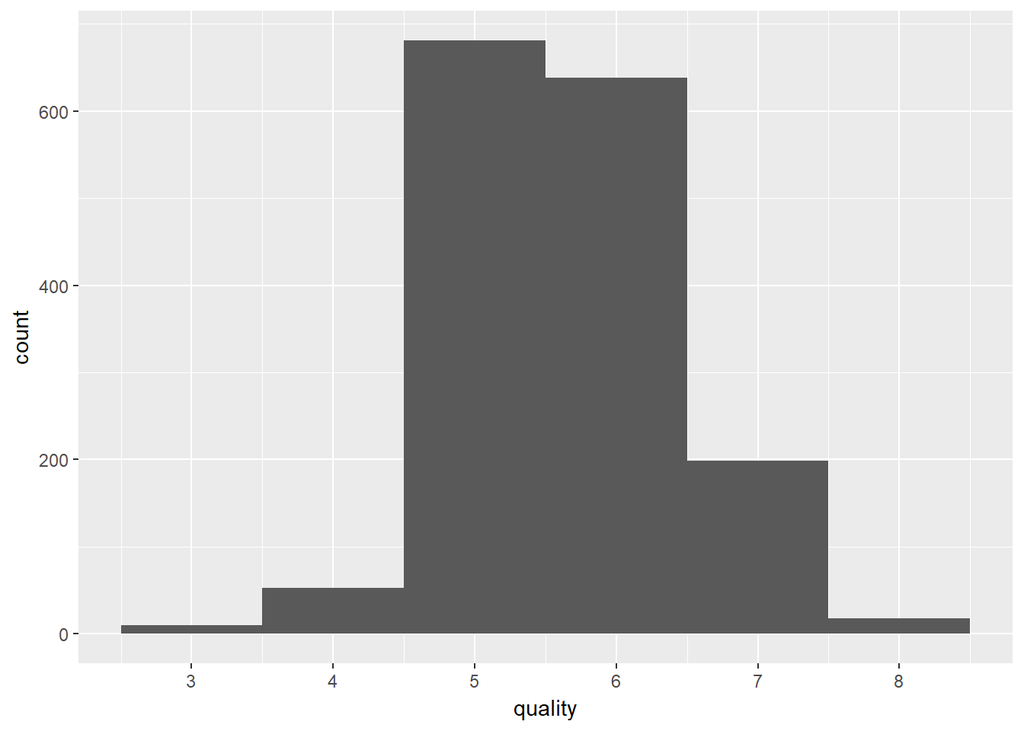

The wine quality follows a normal distribution with most wines being a 5 or a 6. It seems that not a single wine got a score higher than 8 or lower than 3.

```
##
##   3   4   5   6   7   8
##  10  53 681 638 199  18
```

Most wines have a quality ranking of 5 or 6, with only 10 wines in the dataset being really bad (a ranking of 3) and 18 being really good (a ranking of 8).

```
## reds$quality: 3
##    Min. 1st Qu.  Median    Mean 3rd Qu.    Max.
##   8.400   9.725   9.925   9.955  10.575  11.000
## --------------------------------------------------------
## reds$quality: 4
##    Min. 1st Qu.  Median    Mean 3rd Qu.    Max.
##    9.00    9.60   10.00   10.27   11.00   13.10
## --------------------------------------------------------
## reds$quality: 5
##    Min. 1st Qu.  Median    Mean 3rd Qu.    Max.
##     8.5     9.4     9.7     9.9    10.2    14.9
## --------------------------------------------------------
## reds$quality: 6
##    Min. 1st Qu.  Median    Mean 3rd Qu.    Max.
##    8.40    9.80   10.50   10.63   11.30   14.00
## --------------------------------------------------------
## reds$quality: 7
##    Min. 1st Qu.  Median    Mean 3rd Qu.    Max.
##    9.20   10.80   11.50   11.47   12.10   14.00
## --------------------------------------------------------
## reds$quality: 8
##    Min. 1st Qu.  Median    Mean 3rd Qu.    Max.
##    9.80   11.32   12.15   12.09   12.88   14.00
```

```
##    Min. 1st Qu.  Median    Mean 3rd Qu.    Max.
##    8.40    9.50   10.20   10.42   11.10   14.90
```

```
##   X fixed.acidity volatile.acidity citric.acid residual.sugar chlorides
## 1 1           7.4             0.70        0.00            1.9     0.076
## 2 2           7.8             0.88        0.00            2.6     0.098
## 3 3           7.8             0.76        0.04            2.3     0.092
## 4 4          11.2             0.28        0.56            1.9     0.075
## 5 5           7.4             0.70        0.00            1.9     0.076
## 6 6           7.4             0.66        0.00            1.8     0.075
##   free.sulfur.dioxide total.sulfur.dioxide density   pH sulphates alcohol
## 1                  11                   34  0.9978 3.51      0.56     9.4
## 2                  25                   67  0.9968 3.20      0.68     9.8
## 3                  15                   54  0.9970 3.26      0.65     9.8
## 4                  17                   60  0.9980 3.16      0.58     9.8
## 5                  11                   34  0.9978 3.51      0.56     9.4
## 6                  13                   40  0.9978 3.51      0.56     9.4
##   quality alcohol_ranking
## 1       5             low
## 2       5      medium-low
## 3       5      medium-low
## 4       6      medium-low
## 5       5             low
## 6       5             low
```

Here I created a new variable that classifies each wine as low, medium-low, medium-high or high according to the distribution of quantiles in the alcohol variable.

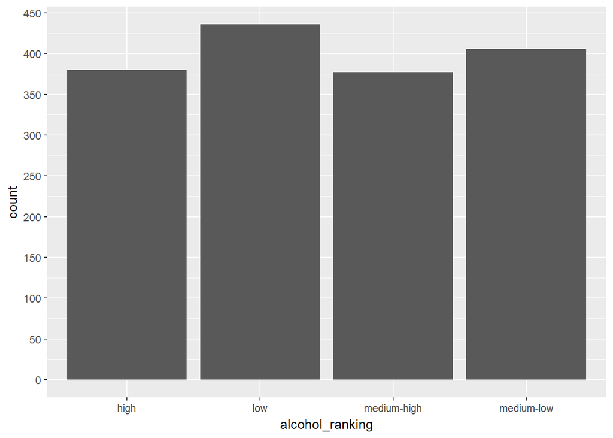

```r
ggplot(aes(x = alcohol_ranking), data = reds) +
  geom_bar() +
  scale_y_continuous(breaks = seq(0, 500, 50))
```

```r
table(reds$alcohol_ranking)
```

```
##
##        high         low medium-high  medium-low
##         380         436         377         406
```

This graph shows the count for each alcohol ranking. Most wines (436) have a ranking of low alcohol, which is below 9.50, followed by the medium-low category, with 406 observations. The high and medium-high rankings followed behind with 380 and 377 observations each.

# Univariate Analysis

### What is the structure of your dataset?

The data set is made of 1599 observations of red wines with 11 variables that describe their chemical properties.

### What is/are the main feature(s) of interest in your dataset?

The main feature of interest in the dataset is the quality ranking for each wine. It might be really interesting to find out what factors affect the quality of wine the most.

### What other features in the dataset do you think will help support your investigation into your feature(s) of interest?

I think alcohol content, volatile acidity, citric acid, chlorides and sulphates might be the chemical properties that could have the most weight when determining the quality of wine.

### Did you create any new variables from existing variables in the dataset?

I created the variable alcohol_ranking, using the quantiles of the alcohol sample, I classified each wine either as low, medium low, medium high, or high. Finally, I converted that variable into a factor because that will be really useful when performing multiple variable analysis.

### Of the features you investigated, were there any unusual distributions? Did you perform any operations on the data to tidy, adjust, or change the form of the data? If so, why did you do this?

Most distributions were right skewed. Just density, pH and quality followed a normal distribution. I didn’t feel the need to change the form of the data, the only modification done was calculating mean, median and quantiles of certain features in order to understand the distributions better.

# Bivariate Plots Section

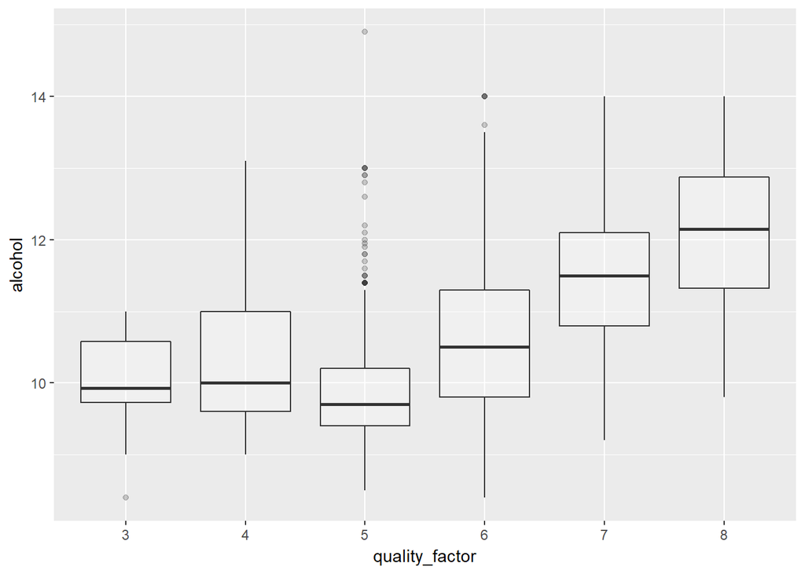

Low quality wines have a small alcohol content mean, with quality #3 having a value around 10, quality 4 moving upwards a little bit, and quality 5 going back down under quality #3, but after that, there is a consistent linear increment in the alcohol content mean as the quality improves, reaching the peak of the distribution at the highest quality.

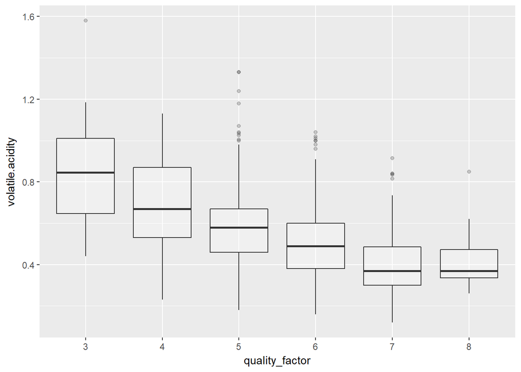

This time we have an inverted trend where volatile acidity decreases as the quality improves. We can notice that high quality wines have a much smaller distribution, with most observations being around the value of .4 for volatile acidity, which is not the case for other wine qualities that have a more spread out distribution.

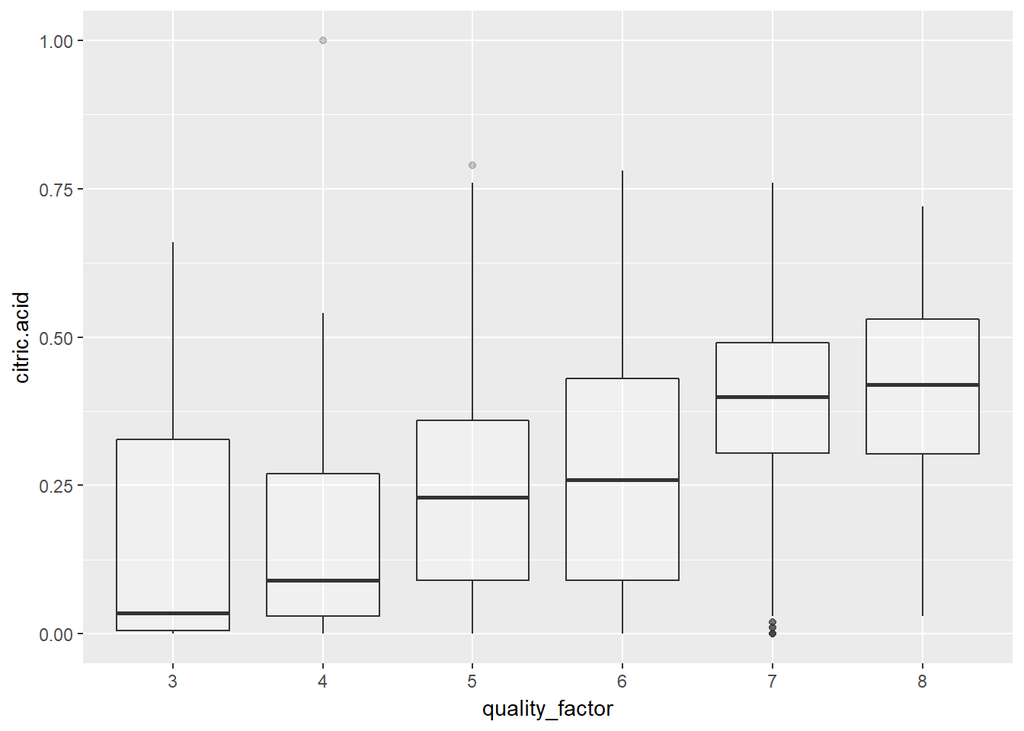

For citric acid, there is a clear trend that shows how citric acid increases as the quality of wine improves.

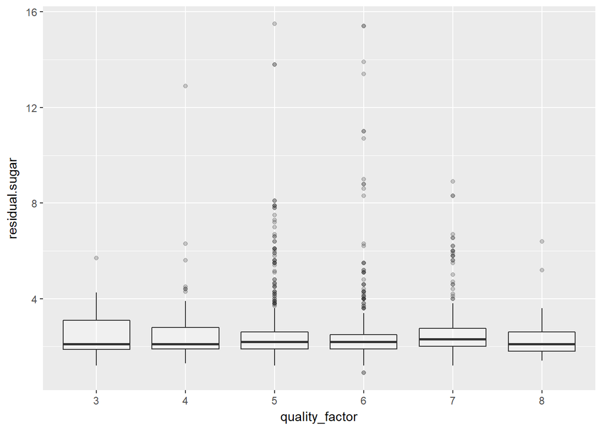

It doesn’t seem that residual sugar is likely to have an impact on quality.

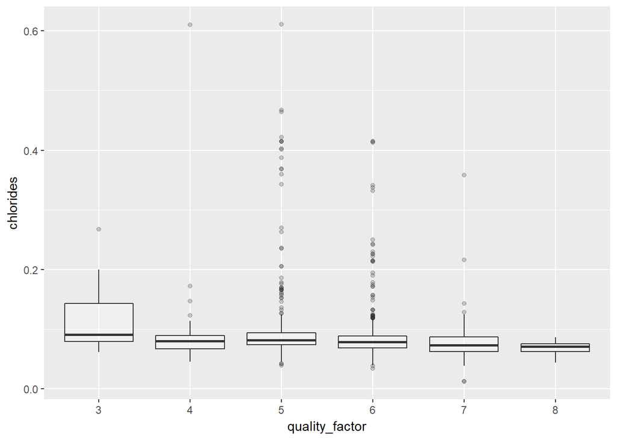

It does seem that higher quality wines usually have a smaller value for chlorides in comparison to lower quality wines, but the differnce is small.

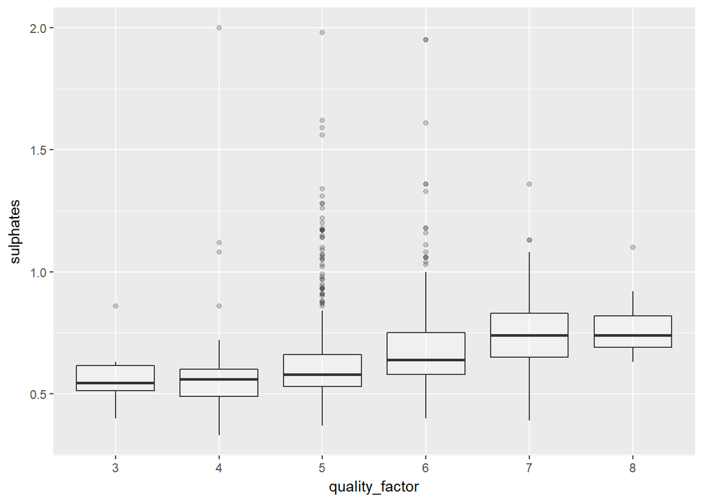

There seems to be a trend where as the wine quality improves, the wine has a higher level of sulphates.

```
## # A tibble: 6 x 4
##   quality alcohol_mean alcohol_median     n
##     <int>        <dbl>          <dbl> <int>
## 1       3         9.96           9.93    10
## 2       4        10.3           10.0     53
## 3       5         9.90           9.70   681
## 4       6        10.6           10.5    638
## 5       7        11.5           11.5    199
## 6       8        12.1           12.2     18
```

```
##
##  Pearson's product-moment correlation
##
## data:  reds$quality and reds$alcohol
## t = 21.639, df = 1597, p-value < 2.2e-16
## alternative hypothesis: true correlation is not equal to 0
## 95 percent confidence interval:
##  0.4373540 0.5132081
## sample estimates:
##       cor
## 0.4761663
```

Running a correlation test we get a result of .476 which is a moderate but meaningful correlation.

```
##
##  Pearson's product-moment correlation
##
## data:  reds$quality and reds$volatile.acidity
## t = -16.954, df = 1597, p-value < 2.2e-16
## alternative hypothesis: true correlation is not equal to 0
## 95 percent confidence interval:
##  -0.4313210 -0.3482032
## sample estimates:
##        cor
## -0.3905578
```

After a correlation test between quality and volatile acidity, we get the result -0.391 which is a small but meaningful correlation.

```
##
##  Pearson's product-moment correlation
##
## data:  reds$quality and reds$citric.acid
## t = 9.2875, df = 1597, p-value < 2.2e-16
## alternative hypothesis: true correlation is not equal to 0
## 95 percent confidence interval:
##  0.1793415 0.2723711
## sample estimates:
##       cor
## 0.2263725
```

After a correlation test between quality and citric acid, we get a result of .226 which indicates that there is not a meaningful relationship between the two variables.

```
##
##  Pearson's product-moment correlation
##
## data:  reds$quality and reds$chlorides
## t = -5.1948, df = 1597, p-value = 2.313e-07
## alternative hypothesis: true correlation is not equal to 0
## 95 percent confidence interval:
##  -0.17681041 -0.08039344
## sample estimates:
##        cor
## -0.1289066
```

After a correlation test between quality and chlorides, we get a result of -0.129, which indicates that there is no meaningful relationship between these two variables.

```
##
##  Pearson's product-moment correlation
##
## data:  reds$quality and reds$sulphates
## t = 10.38, df = 1597, p-value < 2.2e-16
## alternative hypothesis: true correlation is not equal to 0
## 95 percent confidence interval:
##  0.2049011 0.2967610
## sample estimates:
##       cor
## 0.2513971
```

After a correlation test between quality and sulphates, we get a result of .251, which indicates that there is no meaningful relationship between these two variables.

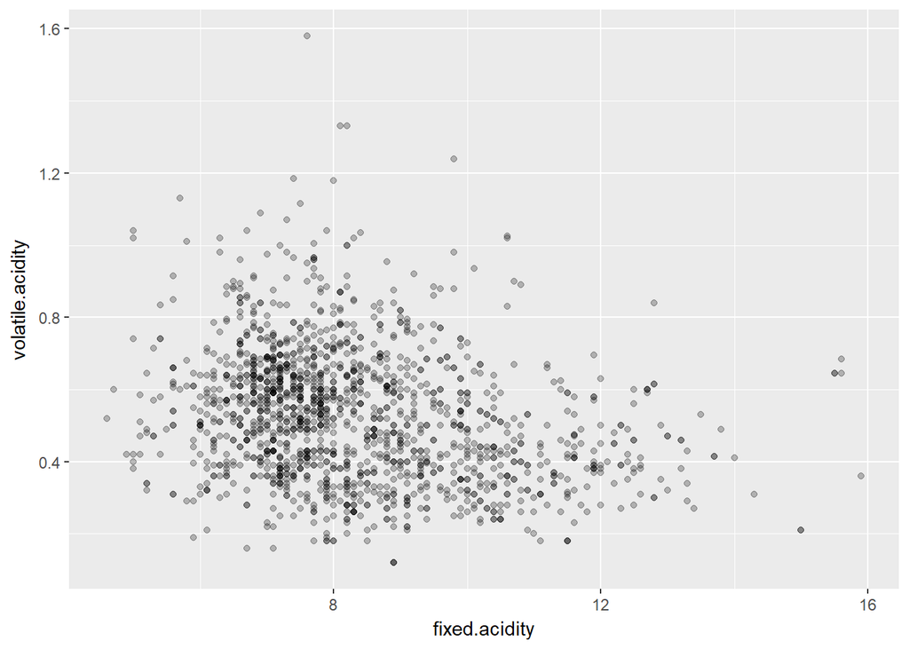

The relationship between fixed acidity and volatile acidity is not very clear. It seems that most observations have a fixed and volatile acidity in the lower half of the range.

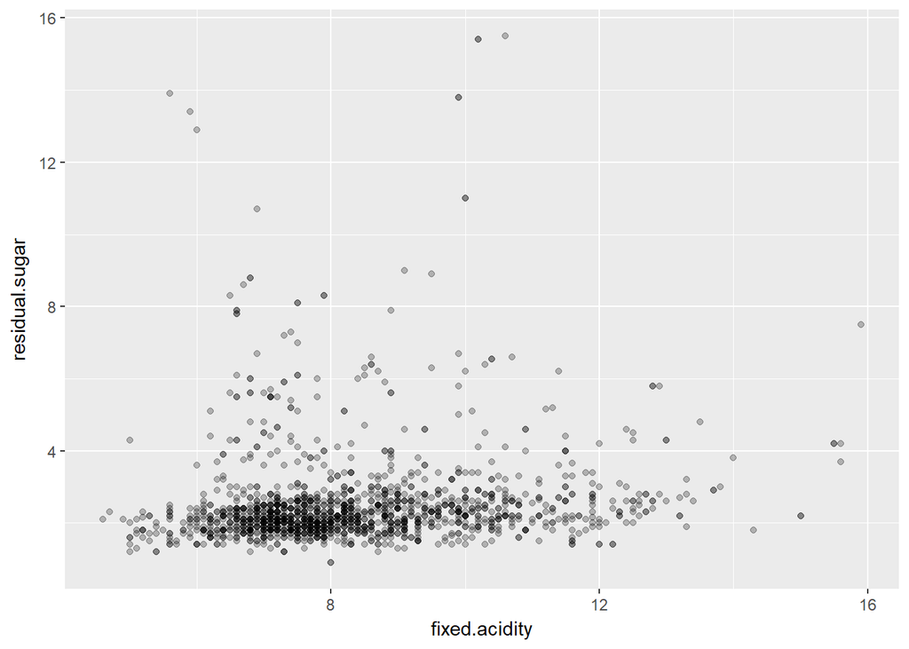

Most wines have a residual sugar level that is less than 4, even across the different levels of fixed acidity. I thought that maybe acidity could be used to balance the sweetness of a wine, so I was hoping to find that wines with a higher level of fixed acidity would be less sweet. This chart doesn’t tell that narrative.

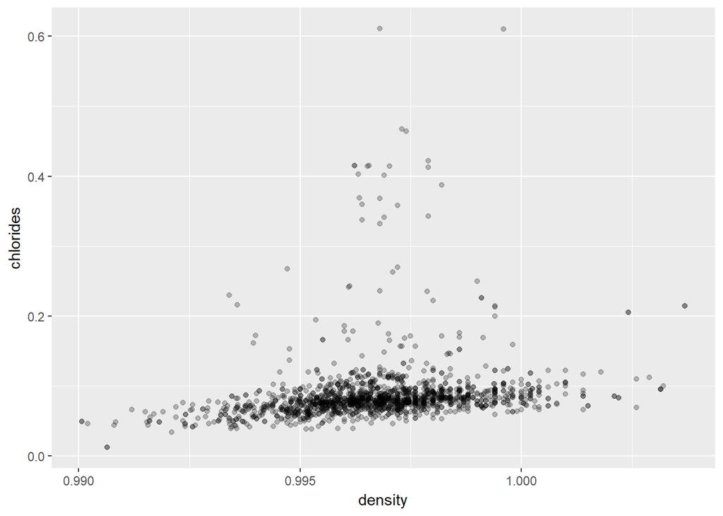

There seems to be a really small trend when chlorides increase so does the density of wine.

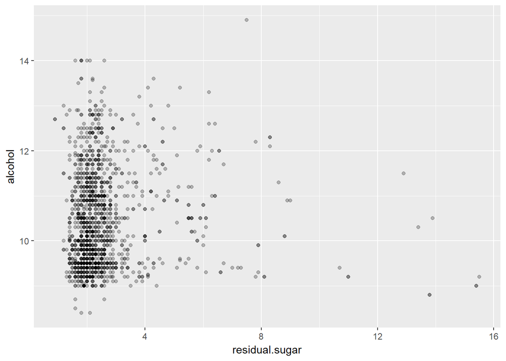

I have heard before that really sweet wines usually have more alcohol. This graph discredits that belief. Most wines, no matter how much alcohol they have, are in the low end of the spectrum regarding residual sugar. Among those outliers with a lot of residual sugar, most of them fall in the low alcohol content category.

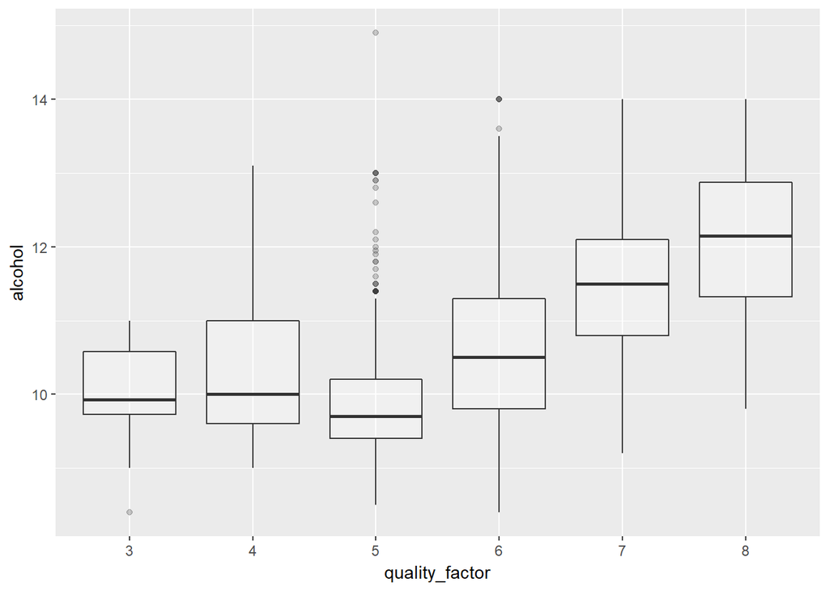